# Analysing data from GEO - Work in Progress

Mark Dunning

Last modified: 29 Jun 2020

# Introduction

In this tutorial we will demonstrate how to download data from Gene Expression Omnibus directly into R. Once loaded, we will perform some quality assessment, differential expression and downstream analysis such as clustering.

We will illustrate the main steps in the workflow. However, some steps may need adjusted for your particular analysis (e.g. changing the model for the differential expression).

You will need to install the following packages before starting:-

```r
install.packages("BiocManager")
install.packages("forcats")
install.packages("stringr")
install.packages("ggplot2")
install.packages("ggrepel")
install.packages("readr")
BiocManager::install("GEOquery")
BiocManager::install("limma")
BiocManager::install("pheatmap")
BiocManager::install("org.Hs.eg.db")
```

You will also need to be familiar with our introductory materials on the `ggplot2` and `dplyr` packages

https://sbc.shef.ac.uk/workshops/2020-03-03-r/crash-course.nb.html#dealing_with_data

# Importing the data

The data from this experiment comprises nine paired tumor/normal colon tissues on Illumina HT12_v3 gene expression Beadchips. We will assume that you already know the accession number (GSE….) for the dataset that you want to download.

The function to download a GEO dataset is `getGEO` from the `GEOquery` package. You have to specify the ID of the dataset that you want. To download your own data, replace `GSE33126` with the ID that you’re interested in.

```r
library(GEOquery)
## change my_id to be the dataset that you want.
my_id <- "GSE33126"
gse <- getGEO(my_id)
```

```
Found 1 file(s)
GSE33126_series_matrix.txt.gz

File stored at:
C:\Users\mjdun\AppData\Local\Temp\RtmpEp2kjf/GPL6947.soft
```

Some datasets on GEO may be derived from different microarray platforms. Therefore the object `gse` is a list of different datasets. You can find out how many were used by checking the length of the `gse` object. Usually there will only be one platform and the dataset we want to analyse will be the first object in the list (`gse[[1]]`).

```r
## check how many platforms used
length(gse)
```

```
[1] 1
```

```r
gse <- gse[[1]]
gse
```

```
ExpressionSet (storageMode: lockedEnvironment)
assayData: 48803 features, 18 samples
  element names: exprs
protocolData: none
phenoData
  sampleNames: GSM820516 GSM820517 ... GSM820533 (18 total)
  varLabels: title geo_accession ... tissue:ch1 (34 total)
  varMetadata: labelDescription
featureData
  featureNames: ILMN_1343291 ILMN_1343295 ... ILMN_2416019 (48803 total)
  fvarLabels: ID nuID ... GB_ACC (30 total)
  fvarMetadata: Column Description labelDescription
experimentData: use 'experimentData(object)'
  pubMedIds: 23028787
Annotation: GPL6947
```

```r
## if more than one dataset is present, you can analyse the other dataset by changing the number inside the [[...]]
## e.g. gse <- gse[[2]]
```

```r
pData(gse) ## print the sample information
fData(gse) ## print the gene annotation
exprs(gse) ## print the expression data
```

# Check the normalisation and scales used

For visualisation and statistical analysis, we will inspect the data to discover what *scale* the data are presented in. The methods we will use assume the data are on a log$_2$ scale; typically in the range of 0 to 16.

The `exprs` function can retrieve the expression values as a data frame; with one column per-sample and one row per-gene.

The `summary` function can then be used to print the distributions.

```r
## exprs get the expression levels as a data frame and get the distribution
summary(exprs(gse))
```

```
   GSM820516         GSM820517         GSM820518         GSM820519         GSM820520
 Min.   :  137.4   Min.   :  132.6   Min.   :  132.6   Min.   :  132.6   Min.   :  132.6
 1st Qu.:  212.1   1st Qu.:  212.1   1st Qu.:  212.0   1st Qu.:  212.1   1st Qu.:  212.0
 Median :  244.9   Median :  245.0   Median :  244.9   Median :  244.9   Median :  244.9
 Mean   : 1247.1   Mean   : 1247.1   Mean   : 1247.0   Mean   : 1247.1   Mean   : 1247.1
 3rd Qu.:  508.2   3rd Qu.:  508.2   3rd Qu.:  508.0   3rd Qu.:  508.2   3rd Qu.:  508.2
 Max.   :71775.3   Max.   :71775.3   Max.   :71775.3   Max.   :71775.3   Max.   :71775.3
   GSM820521         GSM820522         GSM820523         GSM820524         GSM820525
 Min.   :  137.4   Min.   :  132.6   Min.   :  132.6   Min.   :  132.6   Min.   :  132.6
 1st Qu.:  212.1   1st Qu.:  212.1   1st Qu.:  212.1   1st Qu.:  212.1   1st Qu.:  212.1
 Median :  244.9   Median :  244.9   Median :  244.9   Median :  245.0   Median :  245.0
 Mean   : 1247.1   Mean   : 1247.1   Mean   : 1247.1   Mean   : 1247.2   Mean   : 1247.2
 3rd Qu.:  508.2   3rd Qu.:  508.2   3rd Qu.:  508.2   3rd Qu.:  508.2   3rd Qu.:  508.3
 Max.   :71775.3   Max.   :71775.3   Max.   :71775.3   Max.   :71775.3   Max.   :71775.3
   GSM820526         GSM820527         GSM820528         GSM820529         GSM820530
 Min.   :  132.6   Min.   :  132.6   Min.   :  132.6   Min.   :  137.4   Min.   :  132.6
 1st Qu.:  212.0   1st Qu.:  212.1   1st Qu.:  212.1   1st Qu.:  212.1   1st Qu.:  212.1
 Median :  244.9   Median :  245.0   Median :  245.0   Median :  245.0   Median :  244.9
 Mean   : 1247.1   Mean   : 1247.2   Mean   : 1247.1   Mean   : 1247.1   Mean   : 1247.0
 3rd Qu.:  508.3   3rd Qu.:  508.2   3rd Qu.:  508.3   3rd Qu.:  508.2   3rd Qu.:  507.7
 Max.   :71775.3   Max.   :71775.3   Max.   :71775.3   Max.   :71775.3   Max.   :71775.3
   GSM820531         GSM820532         GSM820533
 Min.   :  132.6   Min.   :  132.6   Min.   :  132.6
 1st Qu.:  212.1   1st Qu.:  212.1   1st Qu.:  212.1
 Median :  244.9   Median :  245.0   Median :  245.0
 Mean   : 1247.1   Mean   : 1247.1   Mean   : 1247.1
 3rd Qu.:  507.9   3rd Qu.:  508.1   3rd Qu.:  508.0
 Max.   :71775.3   Max.   :71775.3   Max.   :71775.3
```

From this output we clearly see that the values go beyond 16, so we will need to perform a $log_2$ transformation. A `boxplot` can also be generated to see if the data have been normalised. If so, the distributions of each sample should be highly similar.

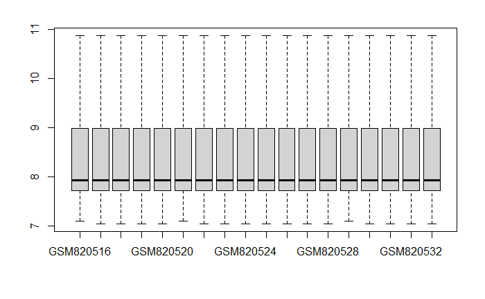

```r
exprs(gse) <- log2(exprs(gse))
boxplot(exprs(gse),outline=FALSE)
```

# Inspect the clinical variables

Data submitted to GEO contain sample labels assigned by the experimenters, and some information about the processing protocol. All these data can be extracted by the `pData` function.

**For your own data, you will have to decide which columns will be useful in the analysis**. This will include the column giving the main comparison(s) of interest and any potential confounding factors. In this particular dataset it looks like `source_name_ch1` and `characteristics_ch1.1`.

We can use the `select` function from `dplyr` to display just these columns of interest. At this stage it will also be useful to rename the columns to something more convenient using the `rename` function.

```r
library(dplyr)
sampleInfo <- pData(gse)
sampleInfo
```

|  | title | geo_accession | status | submission_date | last_update_date | type | channel_count | source_name_ch1 | organism_ch1 | characteristics_ch1 | characteristics_ch1.1 | characteristics_ch1.2 | molecule_ch1 | extract_protocol_ch1 | label_ch1 | label_protocol_ch1 | taxid_ch1 | hyb_protocol | scan_protocol | description | data_processing | platform_id | contact_name | contact_email | contact_institute | contact_address | contact_city | contact_zip/postal_code | contact_country | … |
| --- | --- | --- | --- | --- | --- | --- | --- | --- | --- | --- | --- | --- | --- | --- | --- | --- | --- | --- | --- | --- | --- | --- | --- | --- | --- | --- | --- | --- | --- | --- |
| GSM820516 | C1 (gene expression data) | GSM820516 | Public on Nov 26 2012 | Oct 20 2011 | Nov 26 2012 | RNA | 1 | tumor | Homo sapiens | tissue: Colon | patient: 1 | t=tumor; n=normal: T | total RNA | Tissues were mechanically disrupted and simultaneously homogenized in the presence of QIAzol Lysis reagent (Qiagen, Valencia, CA, USA), using a Mikrodismembrator (Braun Biotech International, Melsunge… | biotin | Total RNA from each sample was labeled according to the manufacturers recommendations. | 9606 | Standard Illumina hybridization protocol | Standard Illumina scanning protocol | 4660559081_A | The data were extracted with BeadStudio software v3.8 | GPL6947 | Loris,,De Cecco | loris.dececco@istitutotumori.mi.it | IRCSS Istituto Nazionale Tumori | via Venezian 1 | Milan | 20133 | Italy | … |
| GSM820517 | C2 (gene expression data) | GSM820517 | Public on Nov 26 2012 | Oct 20 2011 | Nov 26 2012 | RNA | 1 | normal | Homo sapiens | tissue: Colon | patient: 1 | t=tumor; n=normal: N | total RNA | Tissues were mechanically disrupted and simultaneously homogenized in the presence of QIAzol Lysis reagent (Qiagen, Valencia, CA, USA), using a Mikrodismembrator (Braun Biotech International, Melsunge… | biotin | Total RNA from each sample was labeled according to the manufacturers recommendations. | 9606 | Standard Illumina hybridization protocol | Standard Illumina scanning protocol | 4660559081_G | The data were extracted with BeadStudio software v3.8 | GPL6947 | Loris,,De Cecco | loris.dececco@istitutotumori.mi.it | IRCSS Istituto Nazionale Tumori | via Venezian 1 | Milan | 20133 | Italy | … |
| GSM820518 | C3 (gene expression data) | GSM820518 | Public on Nov 26 2012 | Oct 20 2011 | Nov 26 2012 | RNA | 1 | tumor | Homo sapiens | tissue: Colon | patient: 2 | t=tumor; n=normal: T | total RNA | Tissues were mechanically disrupted and simultaneously homogenized in the presence of QIAzol Lysis reagent (Qiagen, Valencia, CA, USA), using a Mikrodismembrator (Braun Biotech International, Melsunge… | biotin | Total RNA from each sample was labeled according to the manufacturers recommendations. | 9606 | Standard Illumina hybridization protocol | Standard Illumina scanning protocol | 4668112004_B | The data were extracted with BeadStudio software v3.8 | GPL6947 | Loris,,De Cecco | loris.dececco@istitutotumori.mi.it | IRCSS Istituto Nazionale Tumori | via Venezian 1 | Milan | 20133 | Italy | … |
| GSM820519 | C4 (gene expression data) | GSM820519 | Public on Nov 26 2012 | Oct 20 2011 | Nov 26 2012 | RNA | 1 | normal | Homo sapiens | tissue: Colon | patient: 2 | t=tumor; n=normal: N | total RNA | Tissues were mechanically disrupted and simultaneously homogenized in the presence of QIAzol Lysis reagent (Qiagen, Valencia, CA, USA), using a Mikrodismembrator (Braun Biotech International, Melsunge… | biotin | Total RNA from each sample was labeled according to the manufacturers recommendations. | 9606 | Standard Illumina hybridization protocol | Standard Illumina scanning protocol | 4668112004_G | The data were extracted with BeadStudio software v3.8 | GPL6947 | Loris,,De Cecco | loris.dececco@istitutotumori.mi.it | IRCSS Istituto Nazionale Tumori | via Venezian 1 | Milan | 20133 | Italy | … |
| GSM820520 | C5 (gene expression data) | GSM820520 | Public on Nov 26 2012 | Oct 20 2011 | Nov 26 2012 | RNA | 1 | tumor | Homo sapiens | tissue: Colon | patient: 3 | t=tumor; n=normal: T | total RNA | Tissues were mechanically disrupted and simultaneously homogenized in the presence of QIAzol Lysis reagent (Qiagen, Valencia, CA, USA), using a Mikrodismembrator (Braun Biotech International, Melsunge… | biotin | Total RNA from each sample was labeled according to the manufacturers recommendations. | 9606 | Standard Illumina hybridization protocol | Standard Illumina scanning protocol | 4668112014_A | The data were extracted with BeadStudio software v3.8 | GPL6947 | Loris,,De Cecco | loris.dececco@istitutotumori.mi.it | IRCSS Istituto Nazionale Tumori | via Venezian 1 | Milan | 20133 | Italy | … |
| GSM820521 | C6 (gene expression data) | GSM820521 | Public on Nov 26 2012 | Oct 20 2011 | Nov 26 2012 | RNA | 1 | normal | Homo sapiens | tissue: Colon | patient: 3 | t=tumor; n=normal: N | total RNA | Tissues were mechanically disrupted and simultaneously homogenized in the presence of QIAzol Lysis reagent (Qiagen, Valencia, CA, USA), using a Mikrodismembrator (Braun Biotech International, Melsunge… | biotin | Total RNA from each sample was labeled according to the manufacturers recommendations. | 9606 | Standard Illumina hybridization protocol | Standard Illumina scanning protocol | 4668112014_H | The data were extracted with BeadStudio software v3.8 | GPL6947 | Loris,,De Cecco | loris.dececco@istitutotumori.mi.it | IRCSS Istituto Nazionale Tumori | via Venezian 1 | Milan | 20133 | Italy | … |
| GSM820522 | C7 (gene expression data) | GSM820522 | Public on Nov 26 2012 | Oct 20 2011 | Nov 26 2012 | RNA | 1 | tumor | Homo sapiens | tissue: Colon | patient: 4 | t=tumor; n=normal: T | total RNA | Tissues were mechanically disrupted and simultaneously homogenized in the presence of QIAzol Lysis reagent (Qiagen, Valencia, CA, USA), using a Mikrodismembrator (Braun Biotech International, Melsunge… | biotin | Total RNA from each sample was labeled according to the manufacturers recommendations. | 9606 | Standard Illumina hybridization protocol | Standard Illumina scanning protocol | 4668112015_A | The data were extracted with BeadStudio software v3.8 | GPL6947 | Loris,,De Cecco | loris.dececco@istitutotumori.mi.it | IRCSS Istituto Nazionale Tumori | via Venezian 1 | Milan | 20133 | Italy | … |
| GSM820523 | C8 (gene expression data) | GSM820523 | Public on Nov 26 2012 | Oct 20 2011 | Nov 26 2012 | RNA | 1 | normal | Homo sapiens | tissue: Colon | patient: 4 | t=tumor; n=normal: N | total RNA | Tissues were mechanically disrupted and simultaneously homogenized in the presence of QIAzol Lysis reagent (Qiagen, Valencia, CA, USA), using a Mikrodismembrator (Braun Biotech International, Melsunge… | biotin | Total RNA from each sample was labeled according to the manufacturers recommendations. | 9606 | Standard Illumina hybridization protocol | Standard Illumina scanning protocol | 4668112015_G | The data were extracted with BeadStudio software v3.8 | GPL6947 | Loris,,De Cecco | loris.dececco@istitutotumori.mi.it | IRCSS Istituto Nazionale Tumori | via Venezian 1 | Milan | 20133 | Italy | … |
| GSM820524 | C9 (gene expression data) | GSM820524 | Public on Nov 26 2012 | Oct 20 2011 | Nov 26 2012 | RNA | 1 | tumor | Homo sapiens | tissue: Colon | patient: 5 | t=tumor; n=normal: T | total RNA | Tissues were mechanically disrupted and simultaneously homogenized in the presence of QIAzol Lysis reagent (Qiagen, Valencia, CA, USA), using a Mikrodismembrator (Braun Biotech International, Melsunge… | biotin | Total RNA from each sample was labeled according to the manufacturers recommendations. | 9606 | Standard Illumina hybridization protocol | Standard Illumina scanning protocol | 4623109073_A | The data were extracted with BeadStudio software v3.8 | GPL6947 | Loris,,De Cecco | loris.dececco@istitutotumori.mi.it | IRCSS Istituto Nazionale Tumori | via Venezian 1 | Milan | 20133 | Italy | … |
| GSM820525 | C10 (gene expression data) | GSM820525 | Public on Nov 26 2012 | Oct 20 2011 | Nov 26 2012 | RNA | 1 | normal | Homo sapiens | tissue: Colon | patient: 5 | t=tumor; n=normal: N | total RNA | Tissues were mechanically disrupted and simultaneously homogenized in the presence of QIAzol Lysis reagent (Qiagen, Valencia, CA, USA), using a Mikrodismembrator (Braun Biotech International, Melsunge… | biotin | Total RNA from each sample was labeled according to the manufacturers recommendations. | 9606 | Standard Illumina hybridization protocol | Standard Illumina scanning protocol | 4623109073_G | The data were extracted with BeadStudio software v3.8 | GPL6947 | Loris,,De Cecco | loris.dececco@istitutotumori.mi.it | IRCSS Istituto Nazionale Tumori | via Venezian 1 | Milan | 20133 | Italy | … |

[output cut: 8 more lines]

```r
## source_name_ch1 and characteristics_ch1.1 seem to contain factors we might need for the analysis. Let's pick just those columns

sampleInfo <- select(sampleInfo, source_name_ch1,characteristics_ch1.1)

## Optionally, rename to more convenient column names
sampleInfo <- rename(sampleInfo,group = source_name_ch1, patient=characteristics_ch1.1)
```

Our sample information is therefore:-

```r
sampleInfo
```

|  | group | patient |
| --- | --- | --- |
| GSM820516 | tumor | patient: 1 |
| GSM820517 | normal | patient: 1 |
| GSM820518 | tumor | patient: 2 |
| GSM820519 | normal | patient: 2 |
| GSM820520 | tumor | patient: 3 |
| GSM820521 | normal | patient: 3 |
| GSM820522 | tumor | patient: 4 |
| GSM820523 | normal | patient: 4 |
| GSM820524 | tumor | patient: 5 |
| GSM820525 | normal | patient: 5 |

[output cut: 8 more lines]

# Sample clustering and Principal Components Analysis

Unsupervised analysis is a good way to get an understanding of the sources of variation in the data. It can also identify potential outlier samples.

The function `cor` can calculate the correlation (on scale 0 - 1) in a pairwise fashion between all samples. This can be then visualised on a heatmap. Among the many options for creating heatmaps in R, the `pheatmap` library is one of the more popular ones. The only argument it requires is a matrix of numerical values (such as the correlation matrix).

```r
library(pheatmap)
## argument use="c" stops an error if there are any missing data points

corMatrix <- cor(exprs(gse),use="c")
pheatmap(corMatrix)
```

We can incorporate sample information onto the plot to try and understand the clustering. We have already created such a data frame previously (`sampleInfo`). However, we need to take care that the rownames of these data match the columns of the correlation matrix.

```r
## Print the rownames of the sample information and check it matches the correlation matrix
rownames(sampleInfo)
```

```
 [1] "GSM820516" "GSM820517" "GSM820518" "GSM820519" "GSM820520" "GSM820521" "GSM820522" "GSM820523"
 [9] "GSM820524" "GSM820525" "GSM820526" "GSM820527" "GSM820528" "GSM820529" "GSM820530" "GSM820531"
[17] "GSM820532" "GSM820533"
```

```r
colnames(corMatrix)
```

```
 [1] "GSM820516" "GSM820517" "GSM820518" "GSM820519" "GSM820520" "GSM820521" "GSM820522" "GSM820523"
 [9] "GSM820524" "GSM820525" "GSM820526" "GSM820527" "GSM820528" "GSM820529" "GSM820530" "GSM820531"
[17] "GSM820532" "GSM820533"
```

```r
## If not, force the rownames to match the columns

rownames(sampleInfo) <- colnames(corMatrix)
pheatmap(corMatrix,
         annotation_col=sampleInfo)
```

A complementary approach is to use Principal Components Analysis (PCA). There is a nice explanation in this youtube video.

https://www.youtube.com/watch?v=0Jp4gsfOLMs

It is important to *transpose* the expression matrix, otherwise R will try and compute PCA on the genes (instead of samples) and quickly run out of memory.

As PCA is an unsupervised method, the known sample groups are not taken into account. However, we can add labels when we plot the results. The `ggplot2` package is particularly convenient for this. The `ggrepel` package can be used to postion the text labels more cleverly so they can be read.

[figure not shown]

```r
library(ggplot2)
library(ggrepel)
## MAKE SURE TO TRANSPOSE THE EXPRESSION MATRIX

pca <- prcomp(t(exprs(gse)))

## Join the PCs to the sample information
cbind(sampleInfo, pca$x) %>%
ggplot(aes(x = PC1, y=PC2, col=group,label=paste("Patient", patient))) + geom_point() + geom_text_repel()
```

## What happens if we spot a batch effect?

Nothing at this stage. Provided the experimental design is sensible (i.e. representatives from all samples groups are present in each batch) we can correct for batch when we run the differential expression analysis.

## What happens if we detect outliers?

If we suspect some samples are outliers we can remove them for further analysis

```r
### CODE ONLY FOR DEMONSTRATION ONLY

### lets' say are outliers are samples 1,2 and 3
## replace 1,2,3 with the outliers in your dataset
outlier_samples <- c(1,2,3)

gse <- gse[,-outlier_samples]
```

# Exporting the data

We can export the expression data to a `csv` for inspection in Excel using the `write_csv` function from `readr`. The expression values themselves will probably not be very useful as they will be named according to manufacturer ID rather than gene name (for example). We can create a matrix by joining the expression matrix with the feature annotation.

```r
library(readr)
full_output <- cbind(fData(gse),exprs(gse))
write_csv(full_output, path="gse_full_output.csv")
```

The annotation from GEO might contain lots of columns that we are not particularly interested in. To keep the data tidier we can use the `select` function to only print particular columns in the output.

```r
features <- fData(gse)
View(features)
### Look at the features data frame and decide the names of the columns you want to keep
features <- select(features,Symbol,Entrez_Gene_ID,Chromosome,Cytoband)
full_output <- cbind(features,exprs(gse))
write_csv(full_output, path="gse_full_output.csv")
```

# Differential Expression

By far the most-popular package for performing differential expression is `limma`. The user-guide is extensive and covers the theory behind the analysis and many use-cases (Chapters 9 and 17 for single-channel data such as Illumina and Affymetrix)

https://bioconductor.org/packages/release/bioc/vignettes/limma/inst/doc/usersguide.pdf

Crucially, we have to allocate the samples in our dataset to the sample groups of interest. A useful function is `model.matrix`, which will create a *design matrix* from one of the columns in your `sampleInfo`. Here I choose `sampleInfo$group`.

The design matrix is a matrix of `0` and `1`s; one row for each sample and one column for each sample group. A `1` in a particular row and column indicates that a given sample (the row) belongs to a given group (column).

```r
library(limma)
design <- model.matrix(~0+sampleInfo$group)
design
```

```
   sampleInfo$groupnormal sampleInfo$grouptumor
1                       0                     1
2                       1                     0
3                       0                     1
4                       1                     0
5                       0                     1
6                       1                     0
7                       0                     1
8                       1                     0
9                       0                     1
10                      1                     0
11                      0                     1
12                      1                     0
13                      0                     1
14                      1                     0
15                      0                     1
16                      1                     0
17                      0                     1
18                      1                     0
attr(,"assign")
[1] 1 1
attr(,"contrasts")
attr(,"contrasts")$`sampleInfo$group`
[1] "contr.treatment"
```

```r
## the column names are a bit ugly, so we will rename
colnames(design) <- c("Normal","Tumour")
```

It has been demonstrated that our power to detect differential expression can be improved if we filter lowly-expressed genes prior to performing the analysis. Quite how one defines a gene being expressed may vary from experiment to experiment, so a cut-off that will work for all datasets is not feasible. Here we consider that aroudn 50% of our genes will not be expressed, and use the median expression level as a cut-off.

```r
summary(exprs(gse))

## calculate median expression level
cutoff <- median(exprs(gse))

## TRUE or FALSE for whether each gene is "expressed" in each sample
is_expressed <- exprs(gse) > cutoff

## Identify genes expressed in more than 2 samples

keep <- rowSums(is_expressed) > 2

## check how many genes are removed / retained.
table(keep)

## subset to just those expressed genes
gse <- gse[keep,]
```

The `lmFit` function is used to fit the model to the data. The result of which is to estimate the expression level in each of the groups that we specified.

```r
fit <- lmFit(exprs(gse), design)
head(fit$coefficients)
```

```
                Normal    Tumour
ILMN_1343291 16.087740 16.004200
ILMN_1343295 14.032346 14.699567
ILMN_1651199  7.786860  7.763617
ILMN_1651209  8.079803  8.002217
ILMN_1651210  7.555458  7.659205
ILMN_1651221  7.816231  7.801812
```

In order to perform the *differential* analysis, we have to define the contrast that we are interested in. In our case we only have two groups and one contrast of interest. Multiple contrasts can be defined in the `makeContrasts` function.

```r
contrasts <- makeContrasts(Tumour - Normal, levels=design)

## can define multiple contrasts
## e.g. makeContrasts(Group1 - Group2, Group2 - Group3,....levels=design)

fit2 <- contrasts.fit(fit, contrasts)
```

Finally, apply the *empirical Bayes’* step to get our differential expression statistics and p-values.

```r
fit2 <- eBayes(fit2)
```

We usually get our first look at the results by using the `topTable` command

```r
topTable(fit2)
```

|  | logFC | AveExpr | t | P.Value | adj.P.Val | B |
| --- | --- | --- | --- | --- | --- | --- |
| ILMN_1704294 | 3.269052 | 9.833508 | 20.85916 | 4.270310e-14 | 2.084039e-09 | 19.87723 |
| ILMN_1813704 | 4.749574 | 10.782232 | 15.82024 | 4.927422e-12 | 1.202365e-07 | 16.50749 |
| ILMN_1724686 | 3.627208 | 10.814662 | 15.12049 | 1.056845e-11 | 1.719240e-07 | 15.91540 |
| ILMN_1811598 | -2.380786 | 9.150986 | -13.57845 | 6.358124e-11 | 7.757388e-07 | 14.47449 |
| ILMN_1659990 | 1.259224 | 8.898440 | 12.63142 | 2.086244e-10 | 2.036299e-06 | 13.48578 |
| ILMN_1763749 | -5.039637 | 11.894505 | -12.24586 | 3.455391e-10 | 2.810558e-06 | 13.05824 |
| ILMN_1652431 | -5.998422 | 11.580616 | -11.74902 | 6.746951e-10 | 4.703878e-06 | 12.48460 |
| ILMN_1702858 | -1.511602 | 9.233874 | -11.54055 | 8.993340e-10 | 5.486275e-06 | 12.23599 |
| ILMN_1663866 | 2.038634 | 14.040020 | 10.91810 | 2.173782e-09 | 1.178746e-05 | 11.46451 |
| ILMN_1809456 | -1.181448 | 8.365228 | -10.66005 | 3.169361e-09 | 1.344462e-05 | 11.13140 |

The `topTable` function automatically displays the results for the first contrast. If you want to see results for other contrasts

```r
topTable(fit2, coef=1)
```

|  | logFC | AveExpr | t | P.Value | adj.P.Val | B |
| --- | --- | --- | --- | --- | --- | --- |
| ILMN_1704294 | 3.269052 | 9.833508 | 20.85916 | 4.270310e-14 | 2.084039e-09 | 19.87723 |
| ILMN_1813704 | 4.749574 | 10.782232 | 15.82024 | 4.927422e-12 | 1.202365e-07 | 16.50749 |
| ILMN_1724686 | 3.627208 | 10.814662 | 15.12049 | 1.056845e-11 | 1.719240e-07 | 15.91540 |
| ILMN_1811598 | -2.380786 | 9.150986 | -13.57845 | 6.358124e-11 | 7.757388e-07 | 14.47449 |
| ILMN_1659990 | 1.259224 | 8.898440 | 12.63142 | 2.086244e-10 | 2.036299e-06 | 13.48578 |
| ILMN_1763749 | -5.039637 | 11.894505 | -12.24586 | 3.455391e-10 | 2.810558e-06 | 13.05824 |
| ILMN_1652431 | -5.998422 | 11.580616 | -11.74902 | 6.746951e-10 | 4.703878e-06 | 12.48460 |
| ILMN_1702858 | -1.511602 | 9.233874 | -11.54055 | 8.993340e-10 | 5.486275e-06 | 12.23599 |
| ILMN_1663866 | 2.038634 | 14.040020 | 10.91810 | 2.173782e-09 | 1.178746e-05 | 11.46451 |
| ILMN_1809456 | -1.181448 | 8.365228 | -10.66005 | 3.169361e-09 | 1.344462e-05 | 11.13140 |

```r
### to see the results of the second contrast (if it exists)
## topTable(fit2, coef=2)
```

If we want to know how many genes are differentially-expressed overall we can use the `decideTests` function.

```r
decideTests(fit2)
```

```
TestResults matrix
              Contrasts
               Tumour - Normal
  ILMN_1343291               0
  ILMN_1343295               0
  ILMN_1651199               0
  ILMN_1651209               0
  ILMN_1651210               0
48798 more rows ...
```

```r
table(decideTests(fit2))
```

```
   -1     0     1
 1097 46219  1487
```

## Coping with outliers

It is tempting to discard any arrays which seem to be outliers prior to differential expressions. However, this is done at the expense of sample-size which could be an issue for small experiments. A compromise, which has been shown to work well is to calculate *weights* to define the reliability of each sample.

Ritchie, M. E., Diyagama, D., Neilson, van Laar, R., J., Dobrovic, A., Holloway, A., and Smyth, G. K. (2006). Empirical array quality weights in the analysis of microarray data. BMC Bioinformatics 7, 261. http://www.biomedcentral.com/1471-2105/7/261

The `arrayWeights` function will assign a score to each sample; with a value of 1 implying equal weight. Samples with score less than 1 are down-weights, and samples with scores greater than 1 are up-weighted. Therefore no samples actually need to be removed.

```r
## calculate relative array weights
aw <- arrayWeights(exprs(gse),design)
aw
```

```
        1         2         3         4         5         6         7         8         9        10
1.0941904 0.7792316 0.8795979 0.8149897 1.1027797 1.1832412 1.0416964 0.9044246 0.9260245 0.9283017
       11        12        13        14        15        16        17        18
0.8567824 1.3450707 1.3738622 1.1054466 0.9272203 1.1598047 0.7926736 1.0376677
```

The `lmFit` function can accept weights, and the rest of the code proceeds as above.

```r
fit <- lmFit(exprs(gse), design,
             weights = aw)
contrasts <- makeContrasts(Tumour - Normal, levels=design)
fit2 <- contrasts.fit(fit, contrasts)
fit2 <- eBayes(fit2)
```

# Further processing and visualisation of DE results

At the moment our results are not particularly easy to navigate as the only information to identify each gene is the identifier that the microarray manufacturer has assigned. Fortunately, the GEO entry contains extensive annotation that we can add. The annotation data can be retrieved with the `fData` function and we restrict to columns we are interested in using `select`.

**For your own data, you will have to choose the columns that are of interest to you. You probably won’t have the same column headings used here**.

Once an annotation data frame has been created, it can be assigned to our results.

```r
anno <- fData(gse)
anno
```

|  | ID | nuID | Species | Source | Search_Key | Transcript | ILMN_Gene | Source_Reference_ID | RefSeq_ID | Unigene_ID | Entrez_Gene_ID | GI | Accession | Symbol | Protein_Product | Array_Address_Id | Probe_Type | Probe_Start | SEQUENCE | Chromosome | Probe_Chr_Orientation | Probe_Coordinates | Cytoband | Definition | Ontology_Component | Ontology_Process | Ontology_Function | Synonyms | Obsolete_Probe_Id | … |
| --- | --- | --- | --- | --- | --- | --- | --- | --- | --- | --- | --- | --- | --- | --- | --- | --- | --- | --- | --- | --- | --- | --- | --- | --- | --- | --- | --- | --- | --- | --- |
| ILMN_1343291 | ILMN_1343291 | 97viJ90hzUX_rZ.nvY | Homo sapiens | RefSeq | ILMN_137991 | ILMN_5311 | EEF1A1 | NM_001402.5 | NM_001402.5 |  | 1915 | 83367078 | NM_001402.5 | EEF1A1 | NP_001393.1 | 3450719 | S | 1294 | TGTGTTGAGAGCTTCTCAGACTATCCACCTTTGGGTCGCTTTGCTGTTCG | 6 | - | 74284362-74284378:74284474-74284506 | 6q13c | Homo sapiens eukaryotic translation elongation factor 1 alpha 1 (EEF1A1), mRNA. | cytoplasm [goid 5737] [evidence NAS] | protein biosynthesis [goid 6412] [evidence IEA]; translational elongation [goid 6414] [pmid 3570288] [evidence NAS] | GTP binding [goid 5525] [evidence IEA]; GTPase activity [goid 3924] [pmid 3570288] [evidence NAS]; nucleotide binding [goid 166] [evidence IEA]; protein binding [goid 5515] [pmid 15231747] [evidence I… | EEF1A; FLJ25721; CCS-3; PTI1; CCS3; MGC102687; MGC16224; EF-Tu; eEF1A-1; EEF-1; MGC131894; HNGC:16303; GRAF-1EF; LENG7; EF1A | PTI1; eEF1A-1; EEF1A; MGC16224; EF-Tu; EEF-1; HNGC:16303; GRAF-1EF; LENG7; EF1A | … |
| ILMN_1343295 | ILMN_1343295 | 9fQSYRUddRf4Z6p6T4 | Homo sapiens | RefSeq | GAPDH | ILMN_27206 | GAPDH | NM_002046.3 | NM_002046.3 |  | 2597 | 83641890 | NM_002046.3 | GAPDH | NP_002037.2 | 4490161 | S | 937 | CTTCAACAGCGACACCCACTCCTCCACCTTTGACGCTGGGGCTGGCATTG | 12 | + | 6517320-6517369 | 12p13.31d | Homo sapiens glyceraldehyde-3-phosphate dehydrogenase (GAPDH), mRNA. | cytoplasm [goid 5737] [evidence NAS] | glucose metabolism [goid 6006] [evidence IEA]; glycolysis [goid 6096] [evidence NAS] | oxidoreductase activity [goid 16491] [evidence IEA]; NAD binding [goid 51287] [evidence IEA]; glyceraldehyde-3-phosphate dehydrogenase (phosphorylating) activity [goid 4365] [pmid 3170585] [evidence N… | G3PD; GAPD; MGC88685 | G3PD; GAPD; MGC88685 | … |
| ILMN_1651199 | ILMN_1651199 | 6OYpVKvaVZJlni1ChY | Homo sapiens | RefSeq | ILMN_45326 | ILMN_46046 | LOC643334 | XM_944551.1 | XM_944551.1 |  | 643334 | 88959248 | XM_944551.1 | LOC643334 | XP_949644.1 | 1770632 | S | 1 | ATGCGAGGCCCCAGGGTTCGGCCCCGCAGCGCCGCTGAGTCCAAGGACCG |  |  |  | 2q37.3b | PREDICTED: Homo sapiens hypothetical LOC643334 (LOC643334), mRNA. |  |  |  |  |  | … |
| ILMN_1651209 | ILMN_1651209 | 60abGV06oA3Va4f0rU | Homo sapiens | RefSeq | ILMN_8692 | ILMN_8692 | SLC35E2 | NM_182838.1 | NM_182838.1 |  | 9906 | 33469136 | NM_182838.1 | SLC35E2 | NP_878258.1 | 2940221 | S | 1103 | TCACGGCGTACGCCCTCATGGGGAAAATCTCCCCGGTGACTTTCAGGTCC | 1 | - | 940247-940251:942395-942439 | 1p36.33a | Homo sapiens solute carrier family 35, member E2 (SLC35E2), mRNA. |  |  |  | MGC117254; MGC138494; DKFZp686M0869; FLJ34996; FLJ44537; MGC126715; MGC104754; KIAA0447 | MGC117254; MGC138494; DKFZp686M0869; MGC126715; MGC104754; KIAA0447 | … |
| ILMN_1651210 | ILMN_1651210 | o7oTiLy97.l5Guommw | Homo sapiens | RefSeq | ILMN_138115 | ILMN_138115 | DUSP22 | XM_941691.1 | XM_941691.1 |  | 56940 | 89070645 | XM_941691.1 | DUSP22 | XP_946784.1 | 380154 | I | 2975 | TGTGGACATGAGAGTTAGTTCTGTTTTGCCTGCACGGTGGGAGCGGCGTA |  |  |  | 6p25.3b | PREDICTED: Homo sapiens dual specificity phosphatase 22 (DUSP22), mRNA. |  |  |  |  |  | … |
| ILMN_1651221 | ILMN_1651221 | EllV59GiXrVNBZYKng | Homo sapiens | RefSeq | ILMN_33528 | ILMN_33528 | LOC642820 | XM_926225.1 | XM_926225.1 |  | 642820 | 89031535 | XM_926225.1 | LOC642820 | XP_931318.1 | 2490538 | S | 61 | GCCGCCCCCTGCTTCACGGAGCCTGGTCCCATCAACCGCCGAAGGGCTGA | 10 | + | 83534280-83534329 |  | PREDICTED: Homo sapiens hypothetical protein LOC642820 (LOC642820), mRNA. |  |  |  |  |  | … |
| ILMN_1651228 | ILMN_1651228 | fZRGweI51.AwJv7v0I | Homo sapiens | RefSeq | ILMN_992 | ILMN_992 | RPS28 | NM_001031.4 | NM_001031.4 |  | 6234 | 71565158 | NM_001031.4 | RPS28 | NP_001022.1 | 650349 | S | 329 | CGCCACACGTAACTGAGATGCTCCTTTAAATAAAGCGTTTGTGTTTCAAG | 19 | + | 8041264-8041313 | 19p13.2d | Homo sapiens ribosomal protein S28 (RPS28), mRNA. | intracellular [goid 5622] [evidence IEA]; cytosolic small ribosomal subunit (sensu Eukaryota) [goid 5843] [pmid 15883184] [evidence IDA] | protein biosynthesis [goid 6412] [pmid 15883184] [evidence IC ] | structural constituent of ribosome [goid 3735] [pmid 15883184] [evidence IDA] |  |  | … |
| ILMN_1651229 | ILMN_1651229 | 9EIpq4KI64KL0R57lo | Homo sapiens | RefSeq | ILMN_10123 | ILMN_10123 | IPO13 | NM_014652.2 | NM_014652.2 |  | 9670 | 41281424 | NM_014652.2 | IPO13 | NP_055467.2 | 2510494 | S | 3437 | ACAAGAGGCGGGTGAAGGAGATGGTGAAGGAGTTCACACTGCTGTGCCGG | 1 | + | 44205856-44205905 | 1p34.1f | Homo sapiens importin 13 (IPO13), mRNA. | nucleus [goid 5634] [evidence IEA]; nuclear pore [goid 5643] [evidence IEA]; cytoplasm [goid 5737] [evidence IEA] | protein transport [goid 15031] [evidence IEA] | protein transporter activity [goid 8565] [evidence IEA]; protein binding [goid 5515] [pmid 16189514] [evidence IPI] | RANBP13; KIAA0724; IMP13; KAP13 | KIAA0724; RANBP13; IMP13; KAP13 | … |
| ILMN_1651230 | ILMN_1651230 | 6uO1RLEVKUBV1Se_ec | Homo sapiens | RefSeq | ILMN_33434 | ILMN_33434 | TESSP1 | XR_001529.1 | XR_001529.1 |  | NA | 89040580 | XR_001529.1 | TESSP1 |  | 2940041 | A | 883 | GTGATGTCCCACAGTACACCCAGGCCAAACCCCTCCCAGCTGTTGCTGCT |  |  |  |  | PREDICTED: Homo sapiens testis serine protease 1 (TESSP1), misc RNA. |  |  |  |  |  | … |
| ILMN_1651232 | ILMN_1651232 | cqKdrRDdYiRJTTd0aw | Homo sapiens | RefSeq | ILMN_34533 | ILMN_170711 | LOC653113 | XR_016352.1 | XR_016352.1 |  | 653113 | 113423213 | XR_016352.1 | LOC653113 |  | 1940544 | A | 390 | GGGAGGCTCGGTCACAATCTCCGAGAGCACAGCCATCATCTCTCACGGTA | 12 | - | 8279542-8279591 | 12p13.31b | PREDICTED: Homo sapiens hypothetical LOC653113 (LOC653113), mRNA. |  |  |  |  |  | … |

[output cut: 990 more lines]

```r
anno <- select(anno,Symbol,Entrez_Gene_ID,Chromosome,Cytoband)
fit2$genes <- anno
topTable(fit2)
```

|  | Symbol | Entrez_Gene_ID | Chromosome | Cytoband | logFC | AveExpr | t | P.Value | adj.P.Val | B |
| --- | --- | --- | --- | --- | --- | --- | --- | --- | --- | --- |
| ILMN_1704294 | CDH3 | 1001 | 16 | 16q22.1c | 3.239132 | 9.833508 | 20.43973 | 5.753806e-14 | 2.808030e-09 | 19.85566 |
| ILMN_1813704 | KIAA1199 | 57214 | 15 | 15q25.1b | 4.754412 | 10.782232 | 16.74276 | 1.797814e-12 | 4.386936e-08 | 17.39163 |
| ILMN_1724686 | CLDN1 | 9076 | 3 | 3q28c | 3.668362 | 10.814662 | 15.91440 | 4.265006e-12 | 6.938170e-08 | 16.72858 |
| ILMN_1811598 | ADH1B | 125 | 4 | 4q23b | -2.319065 | 9.150986 | -12.94137 | 1.354179e-10 | 1.374753e-06 | 13.91854 |
| ILMN_1763749 | GUCA2A | 2980 | 1 | 1p34.2b | -5.070977 | 11.894505 | -12.80520 | 1.611114e-10 | 1.374753e-06 | 13.77139 |
| ILMN_1659990 | HIG2 | 29923 | 7 | 7q32.1a | 1.253927 | 8.898440 | 12.76786 | 1.690167e-10 | 1.374753e-06 | 13.73072 |
| ILMN_1702858 | ADHFE1 | 137872 | 8 | 8q13.1b | -1.526642 | 9.233874 | -11.94258 | 5.019946e-10 | 3.499835e-06 | 12.79620 |
| ILMN_1652431 | CA1 | 759 | 8 | 8q21.2b | -6.055252 | 11.580616 | -11.63780 | 7.618131e-10 | 4.647346e-06 | 12.43307 |
| ILMN_2341661 | ETV4 | 2118 | 17 | 17q21.31b | 2.449354 | 8.964522 | 11.26178 | 1.289680e-09 | 6.400873e-06 | 11.97098 |
| ILMN_1709399 | SLC25A34 | 284723 | 1 | 1p36.21a | -1.963232 | 9.177655 | -11.24992 | 1.311574e-09 | 6.400873e-06 | 11.95614 |

The “*Volcano Plot*” function is a common way of visualising the results of a DE analysis. The $x$ axis shows the log-fold change and the $y$ axis is some measure of statistical significance, which in this case is the log-odds, or “B” statistic. A characteristic “volcano” shape should be seen.

First we create a data frame that we can visualise in `ggplot2`. Specifying the `number` argument to `topTable` creates a table containing test results from all genes. We also put the probe IDs as a column rather than row names.

```r
full_results <- topTable(fit2, number=Inf)
full_results <- tibble::rownames_to_column(full_results,"ID")
```

The basic plot is created as follows:-

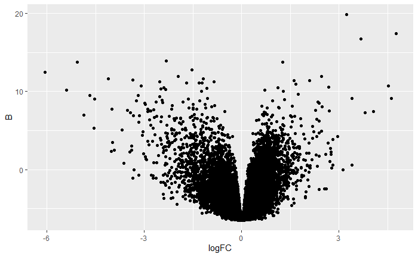

```r
## Make sure you have ggplot2 loaded
library(ggplot2)
ggplot(full_results,aes(x = logFC, y=B)) + geom_point()
```

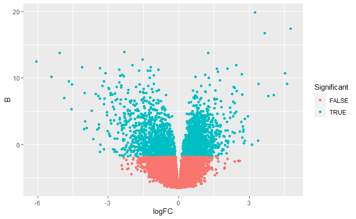

```r
## change according to your needs
p_cutoff <- 0.05
fc_cutoff <- 1

full_results %>%
  mutate(Significant = adj.P.Val < p_cutoff, abs(logFC) > fc_cutoff ) %>%
  ggplot(aes(x = logFC, y = B, col=Significant)) + geom_point()
```

Furthermore, we can label the identity of some genes. Below we set a limit of the top “N” genes we want to label, and label each gene according to it’s `Symbol`.

[figure not shown]

```r
library(ggrepel)
p_cutoff <- 0.05
fc_cutoff <- 1
topN <- 20

full_results %>%
  mutate(Significant = adj.P.Val < p_cutoff, abs(logFC) > fc_cutoff ) %>%
  mutate(Rank = 1:n(), Label = ifelse(Rank < topN, Symbol,"")) %>%
  ggplot(aes(x = logFC, y = B, col=Significant,label=Label)) + geom_point() + geom_text_repel(col="black")
```

# Filtering and exporting the results table

The `filter` function from `dplyr` gives a convenient way to interrogate the table of results.

```r
## Get the results for particular gene of interest
filter(full_results, Symbol == "SMOX")
```

| ID | Symbol | Entrez_Gene_ID | Chromosome | Cytoband | logFC | AveExpr | t | P.Value | adj.P.Val | B |
| --- | --- | --- | --- | --- | --- | --- | --- | --- | --- | --- |
| ILMN_2367258 | SMOX | 54498 | 20 | 20p13b | 1.2783696 | 8.794859 | 9.806782 | 1.129930e-08 | 1.671029e-05 | 10.025394 |
| ILMN_1775380 | SMOX | 54498 | 20 | 20p13b | 1.3185689 | 9.308779 | 9.088456 | 3.593200e-08 | 4.078114e-05 | 8.964750 |
| ILMN_2280707 | SMOX | 54498 | 20 | 20p13b | 0.1586354 | 7.824136 | 1.653966 | 1.153511e-01 | 4.384457e-01 | -5.169693 |

```r
## Get results for genes with TP53 in the name
filter(full_results, grepl("TP53", Symbol))
```

| ID | Symbol | Entrez_Gene_ID | Chromosome | Cytoband | logFC | AveExpr | t | P.Value | adj.P.Val | B |
| --- | --- | --- | --- | --- | --- | --- | --- | --- | --- | --- |
| ILMN_1686906 | TP53INP2 | 58476 | 20 | 20q11.22b | -1.23069086 | 10.864585 | -6.2808050 | 6.178108e-06 | 0.001108493 | 4.103224 |
| ILMN_2358919 | TP53I3 | 9540 | 2 | 2p23.3d | -0.55892208 | 11.092713 | -2.8080369 | 1.158165e-02 | 0.118376744 | -3.122182 |
| ILMN_1764851 | TP53RK | 112858 | 20 | 20q13.12c | 0.42937024 | 10.552431 | 2.6631909 | 1.577866e-02 | 0.142922768 | -3.408521 |
| ILMN_1664440 | TP53BP1 | 7158 | 15 | 15q15.3a | 0.34858370 | 10.809516 | 2.5097280 | 2.178870e-02 | 0.173754036 | -3.704819 |
| ILMN_2159152 | TP53TG3 | 24150 | 16 | 16p11.2b | -0.17723158 | 7.889318 | -1.9765769 | 6.351021e-02 | 0.321924474 | -4.661497 |
| ILMN_2270299 | TP53BP2 | 7159 | 1 | 1q41e-q42.11a | 0.15829663 | 7.825467 | 1.7752633 | 9.265128e-02 | 0.393598569 | -4.985930 |
| ILMN_1779356 | TP53 | 7157 | 17 | 17p13.1d | 0.34615680 | 9.012232 | 1.5806242 | 1.312594e-01 | 0.467969898 | -5.276189 |
| ILMN_2412624 | TP53I11 | 9537 | 11 | 11p11.2d | 0.14345663 | 8.201363 | 1.5623360 | 1.355022e-01 | 0.476366060 | -5.302181 |
| ILMN_1699389 | TP53TG3 | 24150 | 16 | 16p11.2b | 0.09728281 | 7.630901 | 1.3303394 | 1.999060e-01 | 0.568499009 | -5.611289 |
| ILMN_1663932 | TP53TG3 | 24150 | 16 | 16p11.2b | -0.04235651 | 7.680618 | -0.9628654 | 3.482880e-01 | 0.718143815 | -6.014941 |

[output cut: 7 more lines]

```r
## Get results for one chromosome
filter(full_results, Chromosome==20)
```

| ID | Symbol | Entrez_Gene_ID | Chromosome | Cytoband | logFC | AveExpr | t | P.Value | adj.P.Val | B |
| --- | --- | --- | --- | --- | --- | --- | --- | --- | --- | --- |
| ILMN_2367258 | SMOX | 54498 | 20 | 20p13b | 1.2783696179 | 8.794859 | 9.806781680 | 1.129930e-08 | 1.671029e-05 | 10.02539381 |
| ILMN_1775380 | SMOX | 54498 | 20 | 20p13b | 1.3185689121 | 9.308779 | 9.088456467 | 3.593200e-08 | 4.078114e-05 | 8.96474975 |
| ILMN_2358886 | EDN3 | 1908 | 20 | 20q13.32b | -2.4467010501 | 9.994896 | -8.854554145 | 5.306521e-08 | 5.077924e-05 | 8.60406378 |
| ILMN_1753449 | CST1 | 1469 | 20 | 20p11.21b | 2.7013560904 | 9.196262 | 8.182523238 | 1.689406e-07 | 1.043647e-04 | 7.52417216 |
| ILMN_1703205 | EDN3 | 1908 | 20 | 20q13.32b | -2.0148150754 | 9.424641 | -7.655426591 | 4.363896e-07 | 1.918659e-04 | 6.63060592 |
| ILMN_1695687 | SALL4 | 57167 | 20 | 20q13.2a | 1.8253492257 | 8.829982 | 7.089406073 | 1.259970e-06 | 4.099353e-04 | 5.62440133 |
| ILMN_1787815 | TRIB3 | 57761 | 20 | 20p13f | 2.1854323229 | 9.992244 | 7.030431320 | 1.410656e-06 | 4.441563e-04 | 5.51676870 |
| ILMN_1727200 | SLCO4A1 | 28231 | 20 | 20q13.33d | 1.6563597283 | 9.800324 | 6.550155154 | 3.602395e-06 | 8.293213e-04 | 4.62072916 |
| ILMN_1686906 | TP53INP2 | 58476 | 20 | 20q11.22b | -1.2306908645 | 10.864585 | -6.280804986 | 6.178108e-06 | 1.108493e-03 | 4.10322394 |
| ILMN_1662640 | C20orf127 | 140851 | 20 | 20q11.22b | -1.7564907690 | 10.188038 | -6.271979154 | 6.289306e-06 | 1.116135e-03 | 4.08608833 |

[output cut: 875 more lines]

We can also filter according to p-value (adjusted) and fold-change cut-offs

```r
p_cutoff <- 0.05
fc_cutoff <- 1

filter(full_results, adj.P.Val < 0.05, abs(logFC) > 1)
```

| ID | Symbol | Entrez_Gene_ID | Chromosome | Cytoband | logFC | AveExpr | t | P.Value | adj.P.Val | B |
| --- | --- | --- | --- | --- | --- | --- | --- | --- | --- | --- |
| ILMN_1704294 | CDH3 | 1001 | 16 | 16q22.1c | 3.239132 | 9.833508 | 20.439726 | 5.753806e-14 | 2.808030e-09 | 19.85565584 |
| ILMN_1813704 | KIAA1199 | 57214 | 15 | 15q25.1b | 4.754412 | 10.782232 | 16.742757 | 1.797814e-12 | 4.386936e-08 | 17.39162728 |
| ILMN_1724686 | CLDN1 | 9076 | 3 | 3q28c | 3.668362 | 10.814662 | 15.914404 | 4.265006e-12 | 6.938170e-08 | 16.72857607 |
| ILMN_1811598 | ADH1B | 125 | 4 | 4q23b | -2.319065 | 9.150986 | -12.941373 | 1.354179e-10 | 1.374753e-06 | 13.91854423 |
| ILMN_1763749 | GUCA2A | 2980 | 1 | 1p34.2b | -5.070977 | 11.894505 | -12.805203 | 1.611114e-10 | 1.374753e-06 | 13.77138979 |
| ILMN_1659990 | HIG2 | 29923 | 7 | 7q32.1a | 1.253927 | 8.898440 | 12.767863 | 1.690167e-10 | 1.374753e-06 | 13.73072427 |
| ILMN_1702858 | ADHFE1 | 137872 | 8 | 8q13.1b | -1.526642 | 9.233874 | -11.942584 | 5.019946e-10 | 3.499835e-06 | 12.79619969 |
| ILMN_1652431 | CA1 | 759 | 8 | 8q21.2b | -6.055252 | 11.580616 | -11.637802 | 7.618131e-10 | 4.647346e-06 | 12.43307141 |
| ILMN_2341661 | ETV4 | 2118 | 17 | 17q21.31b | 2.449354 | 8.964522 | 11.261784 | 1.289680e-09 | 6.400873e-06 | 11.97098296 |
| ILMN_1709399 | SLC25A34 | 284723 | 1 | 1p36.21a | -1.963232 | 9.177655 | -11.249917 | 1.311574e-09 | 6.400873e-06 | 11.95613962 |

[output cut: 839 more lines]

These results can be exported with the `write_csv` function.

```r
library(readr)
filter(full_results, adj.P.Val < 0.05, abs(logFC) > 1) %>%
  write_csv(path="filtered_de_results.csv")
```

# Further visualisation

## Heatmaps of selected genes

R and Bioconductor have many packages for creating heatmaps. The most popular at the current time `ComplexHeatmap` and `pheatmap` (that we will use here).

Creating the heatmap is pretty straightforward. There is a `pheatmap` function within the `pheatmap` library, and it just needs to know the matrix of values that you want to plot (say `gene_matrix`):-

```r
### example code
library(pheatmap)
pheatmap(gene_matrix)
```

However, there are many different ways of contrusting such a matrix depending on what you want to visualise in the plot. We will consider some options below.

### Most differentially-expressed genes

We have already created a table of differential expression results, which is ranked according to statistical significance.

To visualise the most differentially-expressed genes, we first need to extract their `ID`. These IDs should correspond to rows in the expression matrix.

In the code below we introduce a new column to the results which just gives a row number to each gene. We then filter to return data for the top *N* results. The `pull` function is used to extract the `ID` column as a variable.

```r
## Use to top 20 genes for illustration

topN <- 20
##
ids_of_interest <- mutate(full_results, Rank = 1:n()) %>%
  filter(Rank < topN) %>%
  pull(ID)
```

In order to label the heatmap in a useful manner we extract the corresponding gene symbols.

```r
gene_names <- mutate(full_results, Rank = 1:n()) %>%
  filter(Rank < topN) %>%
  pull(Symbol)
```

The expression values for the IDs we have retrieved can be obtained by using the `[..]` notation to index the expression matrix.

```r
## Get the rows corresponding to ids_of_interest and all columns
gene_matrix <- exprs(gse)[ids_of_interest,]
```

We now make the heatmap. A default colour scheme is used, but can be changed via the arguments. **Please don’t use red and green.**

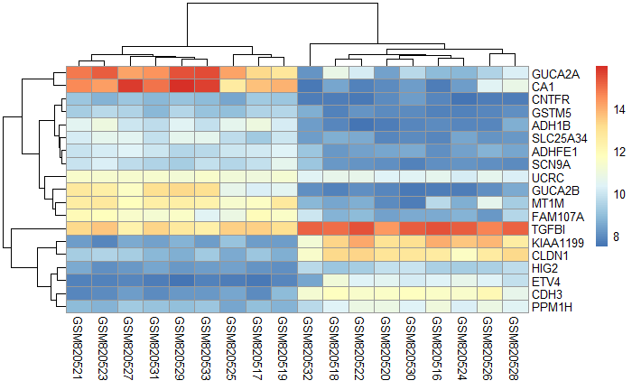

```r
pheatmap(gene_matrix,
     labels_row = gene_names)
```

It is often preferable to scale each row to highlight the differences in each gene across the dataset.

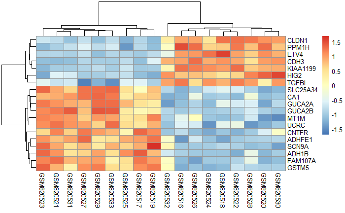

```r
pheatmap(gene_matrix,
     labels_row = gene_names,
     scale="row")
```

### User-defined genes of interest

The procedure is similar to above if you have your own list of genes (e.g. genes from a previous study). The `%in%` function is used to identify rows whose `Symbol` matches any member of `my_genes`. Here we create `my_genes` manually. If you want to plot the genes belonging to a particular *GO* term, it might be more efficient to follow the section below.

Depending on the technology used, there might be multiple matches for a particular gene; so we could end up with more `ID`s than genes. Therefore we repeat the filtering put `pull` the `Symbol` column to make sure we can label the rows of the heatmap.

```r
my_genes <- c("HIG2", "CA1","ETV4","FOXA1")
ids_of_interest <-  filter(full_results,Symbol %in% my_genes) %>%
  pull(ID)

gene_names <-  filter(full_results,Symbol %in% my_genes) %>%
  pull(Symbol)
```

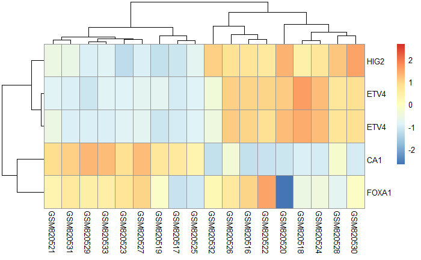

```r
gene_matrix <- exprs(gse)[ids_of_interest,]
pheatmap(gene_matrix,
         labels_row = gene_names,
         scale="row")
```

### For a particular pathway

Bioconductor annotation packages exist for a number of organisms to allow easy conversion between different ID schemes. In this particular use-case we can retrieve the names of genes belonging to a given pathway.

You can check what packages are available from the Bioconductor page (look for the packages named `org.XX.XX.db`)

- [list of Bioconductor organism packages](http://bioconductor.org/packages/release/BiocViews.html#___Organism)

```r
if (!requireNamespace("BiocManager", quietly = TRUE))
    install.packages("BiocManager")

BiocManager::install("org.Hs.eg.db")
```

Once installed, we load the package in the usual manner:-

```r
library(org.Hs.eg.db)
```

Each of these organism packages has a series of keytypes that can we can use to query:-

```r
keytypes(org.Hs.eg.db)
```

```
 [1] "ACCNUM"       "ALIAS"        "ENSEMBL"      "ENSEMBLPROT"  "ENSEMBLTRANS" "ENTREZID"
 [7] "ENZYME"       "EVIDENCE"     "EVIDENCEALL"  "GENENAME"     "GO"           "GOALL"
[13] "IPI"          "MAP"          "OMIM"         "ONTOLOGY"     "ONTOLOGYALL"  "PATH"
[19] "PFAM"         "PMID"         "PROSITE"      "REFSEQ"       "SYMBOL"       "UCSCKG"
[25] "UNIGENE"      "UNIPROT"
```

and a series of columns of data that we can retrieve:-

```r
columns(org.Hs.eg.db)
```

```
 [1] "ACCNUM"       "ALIAS"        "ENSEMBL"      "ENSEMBLPROT"  "ENSEMBLTRANS" "ENTREZID"
 [7] "ENZYME"       "EVIDENCE"     "EVIDENCEALL"  "GENENAME"     "GO"           "GOALL"
[13] "IPI"          "MAP"          "OMIM"         "ONTOLOGY"     "ONTOLOGYALL"  "PATH"
[19] "PFAM"         "PMID"         "PROSITE"      "REFSEQ"       "SYMBOL"       "UCSCKG"
[25] "UNIGENE"      "UNIPROT"
```

To make a query we need to specify a set of *keys* (the IDs that we want to map), what *type* these keys (must match something in the output of `keytypes`) and the columns (the additional data we want).

For illustration, we’ll use the same genes from above (of keytype `SYMBOL`) and retrieve their `ENSEMBL` ID and `GO` terms.

The function required to make the query is also called `select`, but different from the `select` function we have used from `dplyr`. To avoid confusion, we explictly tell R to use the `select` function from `AnnotationDbi` (the package used to query annotation databases automatically installed when we download a database package).

```r
my_genes <- c("HIG2", "CA1","ETV4","FOXA1")

anno <- AnnotationDbi::select(org.Hs.eg.db,
                              columns=c("ENSEMBL","GO"),
                              keys=my_genes,
                              keytype = "SYMBOL")
anno
```

| SYMBOL | ENSEMBL | GO | EVIDENCE | ONTOLOGY |
| --- | --- | --- | --- | --- |
| HIG2 | NA | NA | NA | NA |
| CA1 | ENSG00000133742 | GO:0004064 | IMP | MF |
| CA1 | ENSG00000133742 | GO:0004089 | IMP | MF |
| CA1 | ENSG00000133742 | GO:0005515 | IPI | MF |
| CA1 | ENSG00000133742 | GO:0005829 | TAS | CC |
| CA1 | ENSG00000133742 | GO:0006730 | IEA | BP |
| CA1 | ENSG00000133742 | GO:0008270 | IEA | MF |
| CA1 | ENSG00000133742 | GO:0015701 | TAS | BP |
| CA1 | ENSG00000133742 | GO:0016836 | IDA | MF |
| CA1 | ENSG00000133742 | GO:0035722 | TAS | BP |

[output cut: 63 more lines]

We can use the same function to retrieve genes belonging to a particular pathway with appropriate adjustments to the `columns`, `keys` and `keytype` arguments:-

```r
anno <- AnnotationDbi::select(org.Hs.eg.db,
                              columns="SYMBOL",
                              keys="GO:0006338",
                              keytype="GO")
anno
```

| GO | EVIDENCE | ONTOLOGY | SYMBOL |
| --- | --- | --- | --- |
| GO:0006338 | IC | BP | ACTL6A |
| GO:0006338 | IDA | BP | ACTL6A |
| GO:0006338 | IEA | BP | RERE |
| GO:0006338 | IDA | BP | ATRX |
| GO:0006338 | ISS | BP | BRDT |
| GO:0006338 | IEA | BP | CHD1 |
| GO:0006338 | IDA | BP | DAXX |
| GO:0006338 | IBA | BP | DR1 |
| GO:0006338 | NAS | BP | ESR1 |
| GO:0006338 | ISS | BP | EZH1 |

[output cut: 105 more lines]

```r
my_genes <- pull(anno, SYMBOL)
ids_of_interest <-  filter(full_results,Symbol %in% my_genes) %>%
  pull(ID)

gene_names <-  filter(full_results,Symbol %in% my_genes) %>%
  pull(Symbol)
```

```r
gene_matrix <- exprs(gse)[ids_of_interest,]
pheatmap(gene_matrix,
         labels_row = gene_names,
         scale="row")
```

# Survival Analysis

In this section we give a brief overview of how to perform a survival analysis from a published dataset. The example dataset in question, although quite old, is a useful example of predicting survival in breast cancer.

You will need to install an extra package, `survminer` for the survival analysis itself.

```r
install.packages("survminer")
```

We will use the usual commands for importing the data.

```r
library(GEOquery)
gse <- getGEO('GSE7390')[[1]]
```

We are going to be interested in the phenotypic (/clinical) data stored with the dataset, which will unfortunately require some cleaning prior to analysis. This will be quite a laborious process as there are many variables of interest. For your own dataset, you may need to adapt the code accordingly.

To eye-ball the contents we can use the `View` command in RStudio.

|  | title | geo_accession | status | submission_date | last_update_date | type | channel_count | source_name_ch1 | organism_ch1 | characteristics_ch1 | characteristics_ch1.1 | characteristics_ch1.2 | characteristics_ch1.3 | characteristics_ch1.4 | characteristics_ch1.5 | characteristics_ch1.6 | characteristics_ch1.7 | characteristics_ch1.8 | characteristics_ch1.9 | characteristics_ch1.10 | characteristics_ch1.11 | characteristics_ch1.12 | characteristics_ch1.13 | characteristics_ch1.14 | characteristics_ch1.15 | characteristics_ch1.16 | characteristics_ch1.17 | characteristics_ch1.18 | characteristics_ch1.19 | … |
| --- | --- | --- | --- | --- | --- | --- | --- | --- | --- | --- | --- | --- | --- | --- | --- | --- | --- | --- | --- | --- | --- | --- | --- | --- | --- | --- | --- | --- | --- | --- |
| GSM177885 | VDXGUYU_4002 | GSM177885 | Public on Jun 11 2007 | Mar 28 2007 | May 31 2013 | RNA | 1 | VDXGUYU_4002 | Homo sapiens | samplename: VDXGUYU_4002 | id: 4002 | filename: 10-4002_GUYA.CEL.gz | hospital: GUY | age: 57 | size: 3 | Surgery_type: 0 | Histtype: 1 | Angioinv: 1 | Lymp_infil: 2 | node: 0 | grade: 3 | er: 0 | t.rfs: 723 | e.rfs: 1 | t.os: 937 | e.os: 1 | t.dmfs: 723 | e.dmfs: 1 | t.tdm: 723 | … |
| GSM177886 | VDXGUYU_4008 | GSM177886 | Public on Jun 11 2007 | Mar 28 2007 | May 31 2013 | RNA | 1 | VDXGUYU_4008 | Homo sapiens | samplename: VDXGUYU_4008 | id: 4008 | filename: 26-4008_GUYA.CEL.gz | hospital: GUY | age: 57 | size: 3 | Surgery_type: 0 | Histtype: 2 | Angioinv: 1 | Lymp_infil: 3 | node: 0 | grade: 3 | er: 1 | t.rfs: 183 | e.rfs: 1 | t.os: 6591 | e.os: 0 | t.dmfs: 6591 | e.dmfs: 0 | t.tdm: 6591 | … |
| GSM177887 | VDXGUYU_4011 | GSM177887 | Public on Jun 11 2007 | Mar 28 2007 | May 31 2013 | RNA | 1 | VDXGUYU_4011 | Homo sapiens | samplename: VDXGUYU_4011 | id: 4011 | filename: 6-4011_GUYA.CEL.gz | hospital: GUY | age: 48 | size: 2.5 | Surgery_type: 1 | Histtype: 1 | Angioinv: 0 | Lymp_infil: 2 | node: 0 | grade: 3 | er: 0 | t.rfs: 524 | e.rfs: 1 | t.os: 922 | e.os: 1 | t.dmfs: 524 | e.dmfs: 1 | t.tdm: 524 | … |
| GSM177888 | VDXGUYU_4014 | GSM177888 | Public on Jun 11 2007 | Mar 28 2007 | May 31 2013 | RNA | 1 | VDXGUYU_4014 | Homo sapiens | samplename: VDXGUYU_4014 | id: 4014 | filename: 9-4014_GUYA.CEL.gz | hospital: GUY | age: 42 | size: 1.8 | Surgery_type: 0 | Histtype: 1 | Angioinv: 1 | Lymp_infil: 3 | node: 0 | grade: 3 | er: 1 | t.rfs: 2192 | e.rfs: 1 | t.os: 6255 | e.os: 1 | t.dmfs: 6255 | e.dmfs: 1 | t.tdm: 6255 | … |
| GSM177889 | VDXGUYU_4022 | GSM177889 | Public on Jun 11 2007 | Mar 28 2007 | May 31 2013 | RNA | 1 | VDXGUYU_4022 | Homo sapiens | samplename: VDXGUYU_4022 | id: 4022 | filename: 219-4022_GUYA.CEL.gz | hospital: GUY | age: 46 | size: 3 | Surgery_type: 0 | Histtype: 1 | Angioinv: 1 | Lymp_infil: 2 | node: 0 | grade: 2 | er: 1 | t.rfs: 3822 | e.rfs: 1 | t.os: 4133 | e.os: 1 | t.dmfs: 3822 | e.dmfs: 1 | t.tdm: 3822 | … |
| GSM177890 | VDXGUYU_4033 | GSM177890 | Public on Jun 11 2007 | Mar 28 2007 | May 31 2013 | RNA | 1 | VDXGUYU_4033 | Homo sapiens | samplename: VDXGUYU_4033 | id: 4033 | filename: 17-4033_GUYA.CEL.gz | hospital: GUY | age: 58 | size: 2 | Surgery_type: 0 | Histtype: 2 | Angioinv: 1 | Lymp_infil: 2 | node: 0 | grade: 2 | er: 1 | t.rfs: 6507 | e.rfs: 0 | t.os: 6507 | e.os: 0 | t.dmfs: 6507 | e.dmfs: 0 | t.tdm: 6507 | … |

```r
library(dplyr)
s_data <- pData(gse) %>%
  select(geo_accession, contains("characteristics"), -characteristics_ch1.2, -characteristics_ch1, -characteristics_ch1.1)
```

None of the columns have very convenient names, so we will go ahead and `rename` them.

```r
s_data <- s_data %>%
  rename(hospital = characteristics_ch1.3,
         age = characteristics_ch1.4,
         size = characteristics_ch1.5,
         surgery_type = characteristics_ch1.6,
         histtype = characteristics_ch1.7,
         angioinv = characteristics_ch1.8,
         lymp_infil = characteristics_ch1.9,
         node = characteristics_ch1.10,
         grade = characteristics_ch1.11,
         er = characteristics_ch1.12,
         t.rfs = characteristics_ch1.13,
         e.rfs = characteristics_ch1.14,
         t.os = characteristics_ch1.15,
         e.os = characteristics_ch1.16,
         t.dmfs = characteristics_ch1.17,
         e.dmfs =characteristics_ch1.18,
         t.tdm = characteristics_ch1.19,
         e.tdm = characteristics_ch1.20,
         risksg = characteristics_ch1.21,
         npi = characteristics_ch1.22,
         risknpi = characteristics_ch1.23,
         aol_os_10yr = characteristics_ch1.24,
         risk_aol = characteristics_ch1.25,
         veridex_risk = characteristics_ch1.26)
```

The columns themselves contain entries that are not particularly convenient for analysis. For example, in the `age` column we would expect to find the age of patients in years. Instead each entry is prefixed by the string `age:`, and the same is true for other columns of interest. We can fix this by a performing a *g*lobal *sub*stituion in the offending columns; replacing the prefix with an empty string `""`. See the help on `gsub` for more information. The `dplyr` function `mutate` will save the update column in the data frame.

```r
s_data <- s_data %>%
  mutate(hospital = gsub("hospital: ", "", hospital, fixed=TRUE),
         age = as.numeric(gsub("age: ","", age, fixed=TRUE)),
         size = as.numeric(gsub("size: ","", size, fixed=TRUE)),
         surgery_type = gsub("Surgery_type: ","", surgery_type, fixed=TRUE),
         histtype = gsub("Histtype: ","", histtype, fixed=TRUE),
         angioinv = gsub("Angioinv: ","", angioinv, fixed=TRUE),
         lymp_infil = gsub("Lymp_infil: ","", lymp_infil, fixed=TRUE),
         node = gsub("node: ","", node, fixed=TRUE),
         grade = gsub("grade: ","", grade, fixed=TRUE),
         er = gsub("er: ","", er, fixed=TRUE),
         t.rfs = as.numeric(gsub("t.rfs: ","", t.rfs, fixed=TRUE)),
         e.rfs = as.numeric(gsub("e.rfs: ","", e.rfs, fixed=TRUE)),
         t.os = as.numeric(gsub("t.os: ","", t.os, fixed=TRUE)),
         e.os = as.numeric(gsub("e.os: ","", e.os, fixed=TRUE)),
         t.dmfs = as.numeric(gsub("t.dmfs: ","", t.dmfs, fixed=TRUE)),
         e.dmfs = as.numeric(gsub("e.dmfs: ","", e.dmfs, fixed=TRUE)),
         t.tdm = as.numeric(gsub("t.tdm: ","", t.tdm, fixed=TRUE)),
         e.tdm = as.numeric(gsub("e.tdm: ","", e.tdm, fixed=TRUE)),
         risksg = gsub("risksg: ","", risksg, fixed=TRUE),
         npi = as.numeric(gsub("NPI: ","", npi, fixed=TRUE)),
         risknpi = gsub("risknpi: ","", risknpi, fixed=TRUE),
         aol_os_10yr = as.numeric(gsub("AOL_os_10y: ","", aol_os_10yr, fixed=TRUE)),
         risk_aol = gsub("risk_AOL: ","", risk_aol, fixed=TRUE),
         veridex_risk = gsub("veridex_risk: ","", veridex_risk, fixed=TRUE)
         )
```

```
NAs introduced by coercion
```

Finally we can start to fit survival models to the data. For more detailed explanation of the `survminer` package, the project page has lots of useful information. It is well-known that the Estrogen Receptor (ER) status of a breast cancer is predictive of survival. We have this variable in the `er` column of `s_data`, so can fit the model and plot with the following:-

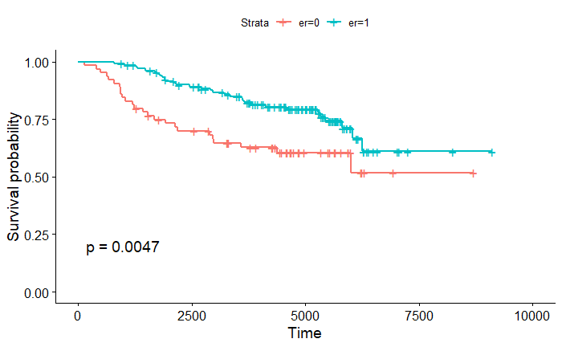

The p-value is significant, as we would hope, with patients having a negative ER status having poorer survival. Other variables can be tested by modifying the formula. For more information on `survminer` see the package documentation at:-

- https://github.com/kassambara/survminer

## Testing Survival association with gene expression

The real utility of having the GEO dataset in a convenient format is to test for associations with the expression level of a particular gene; rather than a pre-defined clinical variable. Thus, we can validate if the genes we are interested in might be predictive of survival. As an example we will use the gene `ESR1` (Estrogen Receptor 1).

We can get a look at the expression values by printing the first five rows and columns. It is quite common for microarray datasets to have each row labelled according to a particular microarray probe identifer (as we have here), so we will need a way of being able to identify genes by their more-common name.

```r
exprs(gse)[1:5,1:5]
```

```
          GSM177885 GSM177886 GSM177887 GSM177888 GSM177889
1007_s_at 10.780787 11.335393 11.028074 11.847736 12.359239
1053_at    8.674201  9.354759  9.053889  9.139895  9.196708
117_at     7.738589  7.763657  6.327600  7.032598  7.873428
121_at     9.285511  9.025809  9.234409  9.656416  9.174188
1255_g_at  6.610484  4.809869  4.621973  5.589404  5.325173
```

More information about the probes is retrieved using the `fData` function.

In this case, the columns of interest are probably `ID` (which should match the rows of our expression matrix) and `Gene Symbol`. For your own data, you will have to work out the names of columns you want to use.

```r
features <- select(features, ID, `Gene Symbol`)
```

[output not shown]

We can also notice that some rows have multiple entries separated by the `///` set of characters. We can split into multiple columns using the `separate` function from `tidyr`.

```r
features <- tidyr::separate(features,`Gene Symbol`, into = c("Symbol_1","Symbol_2"), sep=" /// ")
```

We can now join this to our expression matrix.

```r
e_data <- exprs(gse) %>%
  data.frame %>%
  tibble::rownames_to_column("ID") %>%
  left_join(features)
```

Now that we have gene symbols in the same table as the expression data we can search according to the gene name.

```r
e_data <- filter(e_data,Symbol_1 %in% "ESR1") %>%
  select(-Symbol_1, -Symbol_2)
```

```r
e_data <- e_data %>% tidyr::gather(geo_accession, Expression,-ID) %>%
  tidyr::spread(ID, Expression)
```

We can now join these expression data to our `s_data` data frame that we are using for survival analysis. This is possible because both `s_data` and `e_data` have a column (`geo_accession`) in common.

| geo_accession | hospital | age | size | surgery_type | histtype | angioinv | lymp_infil | node | grade | er | t.rfs | e.rfs | t.os | e.os | t.dmfs | e.dmfs | t.tdm | e.tdm | risksg | npi | risknpi | aol_os_10yr | risk_aol | veridex_risk | 205225_at | 211233_x_at | 211234_x_at | 211235_s_at | 211627_x_at | … |
| --- | --- | --- | --- | --- | --- | --- | --- | --- | --- | --- | --- | --- | --- | --- | --- | --- | --- | --- | --- | --- | --- | --- | --- | --- | --- | --- | --- | --- | --- | --- |
| GSM177885 | GUY | 57 | 3.0 | 0 | 1 | 1 | 2 | 0 | 3 | 0 | 723 | 1 | 937 | 1 | 723 | 1 | 723 | 1 | 2 | 4.60 | 2 | 62.7 | 1 | Poor | 7.933610 | 5.381607 | 6.245238 | 4.546047 | 3.0423531 | … |
| GSM177886 | GUY | 57 | 3.0 | 0 | 2 | 1 | 3 | 0 | 3 | 1 | 183 | 1 | 6591 | 0 | 6591 | 0 | 6591 | 0 | 2 | 4.60 | 2 | 69.0 | 1 | Poor | 12.388468 | 8.323447 | 8.111346 | 7.763822 | 6.4725601 | … |
| GSM177887 | GUY | 48 | 2.5 | 1 | 1 | 0 | 2 | 0 | 3 | 0 | 524 | 1 | 922 | 1 | 524 | 1 | 524 | 1 | 2 | 4.50 | 2 | 66.2 | 1 | Poor | 7.804547 | 7.064502 | 4.292085 | 4.493366 | 2.1235410 | … |
| GSM177888 | GUY | 42 | 1.8 | 0 | 1 | 1 | 3 | 0 | 3 | 1 | 2192 | 1 | 6255 | 1 | 6255 | 1 | 6255 | 0 | 2 | 4.36 | 2 | 84.9 | 1 | Poor | 12.328243 | 8.117395 | 7.662795 | 7.987796 | 3.7848466 | … |
| GSM177889 | GUY | 46 | 3.0 | 0 | 1 | 1 | 2 | 0 | 2 | 1 | 3822 | 1 | 4133 | 1 | 3822 | 1 | 3822 | 1 | 2 | 3.60 | 2 | 80.2 | 1 | Poor | 12.282857 | 8.748458 | 8.531933 | 8.301277 | 5.2152651 | … |
| GSM177890 | GUY | 58 | 2.0 | 0 | 2 | 1 | 2 | 0 | 2 | 1 | 6507 | 0 | 6507 | 0 | 6507 | 0 | 6507 | 0 | 2 | 3.40 | 2 | 83.1 | 1 | Good | 11.917397 | 7.603430 | 6.145443 | 6.973182 | 4.8808296 | … |
| GSM177891 | GUY | 44 | 2.0 | 1 | 1 | 1 | 3 | 0 | 3 | 0 | 709 | 1 | 5947 | 0 | 5947 | 0 | 5947 | 0 | 2 | 4.40 | 2 | 80.6 | 1 | Poor | 6.465295 | 4.680087 | 6.770641 | 5.428167 | 4.9165348 | … |
| GSM177892 | GUY | 58 | 2.5 | 1 | 2 | 1 | 2 | 0 | 1 | 1 | 5816 | 1 | 5816 | 1 | 5816 | 1 | 5816 | 0 | 2 | 2.50 | 1 | 82.1 | 1 | Good | 13.244956 | 9.165501 | 8.790229 | 8.837305 | 3.0457006 | … |
| GSM177893 | GUY | 47 | 3.0 | 0 | 2 | 2 | NA | 0 | 3 | 1 | 6007 | 0 | 6007 | 0 | 6007 | 0 | 6007 | 0 | 2 | 4.60 | 2 | 73.2 | 1 | Poor | 13.660405 | 10.589954 | 10.187169 | 10.173807 | 5.2343956 | … |
| GSM177894 | GUY | 38 | 2.5 | 0 | 2 | 2 | 3 | 0 | 2 | 1 | 422 | 1 | 1484 | 1 | 1233 | 1 | 1233 | 1 | 2 | 3.50 | 2 | 81.5 | 1 | Poor | 11.685040 | 7.726229 | 7.385876 | 7.177648 | 4.9879400 | … |

[output cut: 188 more lines]

As an aside, we can do a quick sanity check as we expect **ESR1** to be lowly-expressed in ER negative tumours.

```
There were 13 warnings (use warnings() to see them)
```

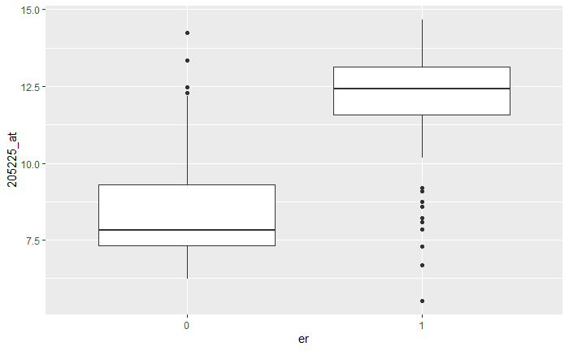

```r
ggplot(s_data, aes(x = er, y =`205225_at`)) + geom_boxplot()
```

As we saw before, the survival analysis requires a grouping variable to split our data (previously we used the `er` column). We can form the groups using the expression from one particular probe

```r
s_data <- mutate(s_data, Group = ifelse(`205225_at` > quantile(`205225_at`,0.75), "High","Low"))
```

```
There were 26 warnings (use warnings() to see them)
```

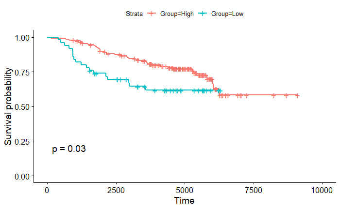

```r
fit <- survfit(Surv(t.os, e.os) ~ Group, data = s_data)
ggsurvplot(fit, data = s_data,pval = TRUE)
```

```r
s_data <- mutate(s_data, Group = cut(`205225_at`, breaks = quantile(`205225_at`,probs=c(0,0.25,0.5,1))))
```

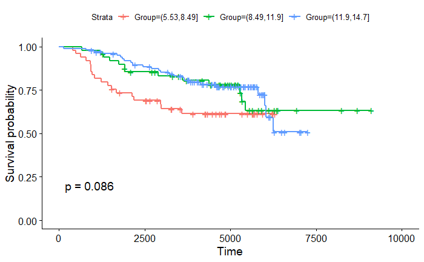

```r
fit <- survfit(Surv(t.os, e.os) ~ Group, data = s_data)
ggsurvplot(fit, data = s_data,pval = TRUE)
```